# ML Assignment Group: 119

## Problem Statement

### Predict whether the credit card using the customer is going to default or not.

- Import the data from the [default of credit card clients](https://archive.ics.uci.edu/ml/datasets/default+of+credit+card+clients) (2 points)
- Consider all columns as independent variables and assign to variable X except the last column and consider the last column as dependent variable and assign to variable y. Remove columns which don’t help the problem statement. (1 point)
- Compute some basic statistical details like percentile, mean, standard deviation of dataset (1 point)
- Do Feature Scaling on Independent variables (2 points)
- Split the data into train and test dataset (1 point)
- Use sklearn library to train on train dataset on random forest and predict on test dataset (3 points)
- Compute the accuracy and confusion matrix. (2 points)

### Contributors

J Manoj Balaji (2019AB04228@wilp.bits-pilani.ac.in)  
Siddharth Verma (2019AD04097@wilp.bits-pilani.ac.in)  
Randeep Singh (2019AD04069@wilp.bits-pilani.ac.in)

## Import necessary dependencies

```python
import numpy as np
import pandas as pd
import matplotlib.pyplot as plt
import seaborn as sns
from collections import Counter
%matplotlib inline
from sklearn.ensemble import RandomForestClassifier
from sklearn.model_selection import train_test_split
from sklearn.preprocessing import StandardScaler
from sklearn.model_selection import train_test_split
from sklearn.metrics import accuracy_score,confusion_matrix,classification_report
```

## Import the dataset

#### Dropping ID variable since that's a unique variable for each row and doesn't help in prediction

```python
df = pd.read_excel('default of credit card clients.xls',skiprows=1,usecols="B:Y")
```

```python
df.head()
```

|  | LIMIT_BAL | SEX | EDUCATION | MARRIAGE | AGE | PAY_0 | PAY_2 | PAY_3 | PAY_4 | PAY_5 | ... | BILL_AMT4 | BILL_AMT5 | BILL_AMT6 | PAY_AMT1 | PAY_AMT2 | PAY_AMT3 | PAY_AMT4 | PAY_AMT5 | PAY_AMT6 | default payment next month |
| --- | --- | --- | --- | --- | --- | --- | --- | --- | --- | --- | --- | --- | --- | --- | --- | --- | --- | --- | --- | --- | --- |
| 0 | 20000 | 2 | 2 | 1 | 24 | 2 | 2 | -1 | -1 | -2 | ... | 0 | 0 | 0 | 0 | 689 | 0 | 0 | 0 | 0 | 1 |
| 1 | 120000 | 2 | 2 | 2 | 26 | -1 | 2 | 0 | 0 | 0 | ... | 3272 | 3455 | 3261 | 0 | 1000 | 1000 | 1000 | 0 | 2000 | 1 |
| 2 | 90000 | 2 | 2 | 2 | 34 | 0 | 0 | 0 | 0 | 0 | ... | 14331 | 14948 | 15549 | 1518 | 1500 | 1000 | 1000 | 1000 | 5000 | 0 |
| 3 | 50000 | 2 | 2 | 1 | 37 | 0 | 0 | 0 | 0 | 0 | ... | 28314 | 28959 | 29547 | 2000 | 2019 | 1200 | 1100 | 1069 | 1000 | 0 |
| 4 | 50000 | 1 | 2 | 1 | 57 | -1 | 0 | -1 | 0 | 0 | ... | 20940 | 19146 | 19131 | 2000 | 36681 | 10000 | 9000 | 689 | 679 | 0 |

5 rows × 24 columns

## Understanding data

#### Computing some basic statistical details like percentile, mean, standard deviation of dataset

```python
df.describe()
```

|  | LIMIT_BAL | SEX | EDUCATION | MARRIAGE | AGE | PAY_0 | PAY_2 | PAY_3 | PAY_4 | PAY_5 | ... | BILL_AMT4 | BILL_AMT5 | BILL_AMT6 | PAY_AMT1 | PAY_AMT2 | PAY_AMT3 | PAY_AMT4 | PAY_AMT5 | PAY_AMT6 | default payment next month |
| --- | --- | --- | --- | --- | --- | --- | --- | --- | --- | --- | --- | --- | --- | --- | --- | --- | --- | --- | --- | --- | --- |
| count | 30000.000000 | 30000.000000 | 30000.000000 | 30000.000000 | 30000.000000 | 30000.000000 | 30000.000000 | 30000.000000 | 30000.000000 | 30000.000000 | ... | 30000.000000 | 30000.000000 | 30000.000000 | 30000.000000 | 3.000000e+04 | 30000.00000 | 30000.000000 | 30000.000000 | 30000.000000 | 30000.000000 |
| mean | 167484.322667 | 1.603733 | 1.853133 | 1.551867 | 35.485500 | -0.016700 | -0.133767 | -0.166200 | -0.220667 | -0.266200 | ... | 43262.948967 | 40311.400967 | 38871.760400 | 5663.580500 | 5.921163e+03 | 5225.68150 | 4826.076867 | 4799.387633 | 5215.502567 | 0.221200 |
| std | 129747.661567 | 0.489129 | 0.790349 | 0.521970 | 9.217904 | 1.123802 | 1.197186 | 1.196868 | 1.169139 | 1.133187 | ... | 64332.856134 | 60797.155770 | 59554.107537 | 16563.280354 | 2.304087e+04 | 17606.96147 | 15666.159744 | 15278.305679 | 17777.465775 | 0.415062 |
| min | 10000.000000 | 1.000000 | 0.000000 | 0.000000 | 21.000000 | -2.000000 | -2.000000 | -2.000000 | -2.000000 | -2.000000 | ... | -170000.000000 | -81334.000000 | -339603.000000 | 0.000000 | 0.000000e+00 | 0.00000 | 0.000000 | 0.000000 | 0.000000 | 0.000000 |
| 25% | 50000.000000 | 1.000000 | 1.000000 | 1.000000 | 28.000000 | -1.000000 | -1.000000 | -1.000000 | -1.000000 | -1.000000 | ... | 2326.750000 | 1763.000000 | 1256.000000 | 1000.000000 | 8.330000e+02 | 390.00000 | 296.000000 | 252.500000 | 117.750000 | 0.000000 |
| 50% | 140000.000000 | 2.000000 | 2.000000 | 2.000000 | 34.000000 | 0.000000 | 0.000000 | 0.000000 | 0.000000 | 0.000000 | ... | 19052.000000 | 18104.500000 | 17071.000000 | 2100.000000 | 2.009000e+03 | 1800.00000 | 1500.000000 | 1500.000000 | 1500.000000 | 0.000000 |
| 75% | 240000.000000 | 2.000000 | 2.000000 | 2.000000 | 41.000000 | 0.000000 | 0.000000 | 0.000000 | 0.000000 | 0.000000 | ... | 54506.000000 | 50190.500000 | 49198.250000 | 5006.000000 | 5.000000e+03 | 4505.00000 | 4013.250000 | 4031.500000 | 4000.000000 | 0.000000 |
| max | 1000000.000000 | 2.000000 | 6.000000 | 3.000000 | 79.000000 | 8.000000 | 8.000000 | 8.000000 | 8.000000 | 8.000000 | ... | 891586.000000 | 927171.000000 | 961664.000000 | 873552.000000 | 1.684259e+06 | 896040.00000 | 621000.000000 | 426529.000000 | 528666.000000 | 1.000000 |

8 rows × 24 columns

```python
df.info()
```

```
<class 'pandas.core.frame.DataFrame'>
RangeIndex: 30000 entries, 0 to 29999
Data columns (total 24 columns):
 #   Column                      Non-Null Count  Dtype
---  ------                      --------------  -----
 0   LIMIT_BAL                   30000 non-null  int64
 1   SEX                         30000 non-null  int64
 2   EDUCATION                   30000 non-null  int64
 3   MARRIAGE                    30000 non-null  int64
 4   AGE                         30000 non-null  int64
 5   PAY_0                       30000 non-null  int64
 6   PAY_2                       30000 non-null  int64
 7   PAY_3                       30000 non-null  int64
 8   PAY_4                       30000 non-null  int64
 9   PAY_5                       30000 non-null  int64
```

[output cut: 16 more lines]

From the dataset, we can see that SEX, EDUCATION, MARIAGE, AGE, PAY_0, PAY_2, PAY_3, PAY_4, PAY_5, PAY_6 are categorical variables and BILL_AMT1, BILL_AMT2, BILL_AMT3, BILL_AMT4, BILL_AMT5, BILL_AMT6, PAY_AMT1, PAY_AMT2, PAY_AMT3, PAY_AMT4, PAY_AMT5, PAY_AMT6, LIMIT_BAL are continuous variables. And as specified in the problem statement, the last column i.e. default payment next month is the target column. We need to scale the values of continuous variables.

From the description mentioned on the dataset repository page [default of credit card clients.](https://archive.ics.uci.edu/ml/datasets/default+of+credit+card+clients) We assign the following list of continous variables

```python
continous_list = ['BILL_AMT1','BILL_AMT2' ,'BILL_AMT3','BILL_AMT4','BILL_AMT5' ,'BILL_AMT6' ,'PAY_AMT1' ,'PAY_AMT2' ,'PAY_AMT3' ,'PAY_AMT4' ,'PAY_AMT5' ,'PAY_AMT6','LIMIT_BAL']
```

```python
categorical_list  = np.setdiff1d(df.columns,continous_list)
categorical_list
```

```
array(['AGE', 'EDUCATION', 'MARRIAGE', 'PAY_0', 'PAY_2', 'PAY_3', 'PAY_4',
       'PAY_5', 'PAY_6', 'SEX', 'default payment next month'],
      dtype=object)
```

```
Unique age values: 56
```

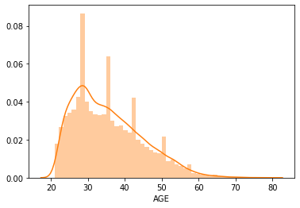

```python
# understand age to decide whether to consider it as Continuous or Categorical, since the values are within a very short range, we can take it as categorical variable
sns.distplot(df.AGE, color='tab:orange')
print('Unique age values:', df.AGE.nunique())
```

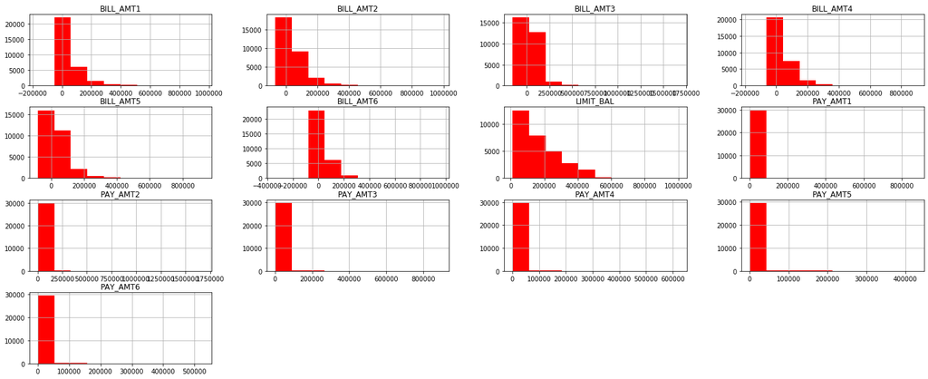

```python
df[continous_list].hist(bins=10, figsize=(25, 10), color='red');
```

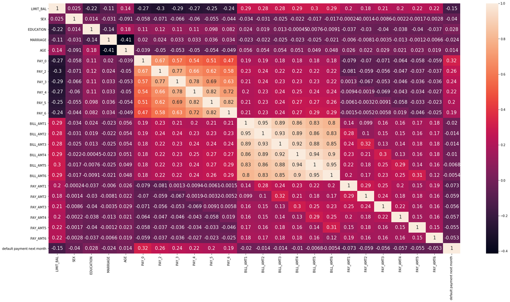

```python
fig, ax = plt.subplots(figsize=(30,15))
sns.heatmap(df.corr(), annot=True, ax=ax, annot_kws={"size": 15})
```

#### Deleting the below attributes because of high correlation amongsts themselves

All BILL_AMT variables have high positive correlation amongsts themselves  
Pay 3 - 6 have high correlation amongsts themselves

```python
continous_list
```

```
['BILL_AMT1',
 'BILL_AMT2',
 'BILL_AMT3',
 'BILL_AMT4',
 'BILL_AMT5',
 'BILL_AMT6',
 'PAY_AMT1',
 'PAY_AMT2',
 'PAY_AMT3',
 'PAY_AMT4',
 'PAY_AMT5',
 'PAY_AMT6',
 'LIMIT_BAL']
```

```python
removable_continous = ['BILL_AMT3' ,'BILL_AMT2' ,'BILL_AMT1','BILL_AMT4','BILL_AMT5' ,'BILL_AMT6']
removable_categorical = ['PAY_3', 'PAY_4', 'PAY_5', 'PAY_6']
df.drop(removable_continous, axis=1, inplace=True)
df.drop(removable_categorical, axis=1, inplace=True)
continous_list = np.asarray(continous_list)
categorical_list = np.asarray(categorical_list)
continous_list = np.setdiff1d(continous_list, removable_continous)
categorical_list = np.setdiff1d(categorical_list, removable_categorical)
print('continous list:',continous_list)
print('categorical list:',categorical_list)
```

```
continous list: ['LIMIT_BAL' 'PAY_AMT1' 'PAY_AMT2' 'PAY_AMT3' 'PAY_AMT4' 'PAY_AMT5'
 'PAY_AMT6']
categorical list: ['AGE' 'EDUCATION' 'MARRIAGE' 'PAY_0' 'PAY_2' 'SEX'
 'default payment next month']
```

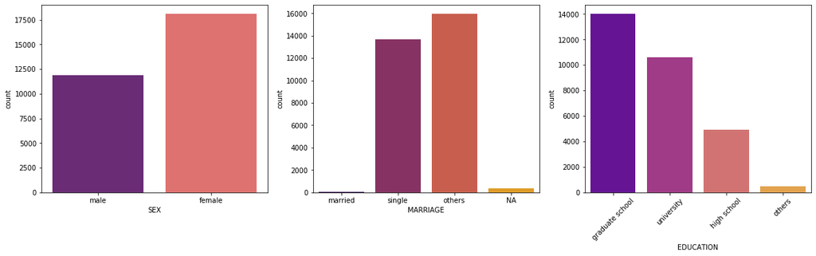

```python
plt.subplots(figsize=(20,5))
plt.subplot(1,3,1)
ax = sns.countplot(df['SEX'], palette = 'magma')
ax.set_xticklabels(['male', 'female'])
plt.subplot(1,3,2)
ax = sns.countplot(df['MARRIAGE'], palette = 'inferno')
ax.set_xticklabels(['married','single','others', 'NA'])
plt.subplot(1,3,3)
ax = sns.countplot(df['EDUCATION'].map({1:'graduate school',2:'university',3:'high school',4:'others',5:'others', 6:'others'}) , palette = 'plasma')
temp = ax.set_xticklabels(['graduate school','university','high school','others'], rotation=45)
```

## Data Preprocessing

#### Feature Scaling on Independent variables

```python
scaler = StandardScaler()
```

```python
continous_transform_df = pd.DataFrame(scaler.fit_transform(df[continous_list]),columns=continous_list)
```

```python
continous_transform_df.head()
```

|  | LIMIT_BAL | PAY_AMT1 | PAY_AMT2 | PAY_AMT3 | PAY_AMT4 | PAY_AMT5 | PAY_AMT6 |
| --- | --- | --- | --- | --- | --- | --- | --- |
| 0 | -1.136720 | -0.341942 | -0.227086 | -0.296801 | -0.308063 | -0.314136 | -0.293382 |
| 1 | -0.365981 | -0.341942 | -0.213588 | -0.240005 | -0.244230 | -0.314136 | -0.180878 |
| 2 | -0.597202 | -0.250292 | -0.191887 | -0.240005 | -0.244230 | -0.248683 | -0.012122 |
| 3 | -0.905498 | -0.221191 | -0.169361 | -0.228645 | -0.237846 | -0.244166 | -0.237130 |
| 4 | -0.905498 | -0.221191 | 1.335034 | 0.271165 | 0.266434 | -0.269039 | -0.255187 |

```python
categorical_df = df[categorical_list]
```

```python
categorical_df.head()
```

|  | AGE | EDUCATION | MARRIAGE | PAY_0 | PAY_2 | SEX | default payment next month |
| --- | --- | --- | --- | --- | --- | --- | --- |
| 0 | 24 | 2 | 1 | 2 | 2 | 2 | 1 |
| 1 | 26 | 2 | 2 | -1 | 2 | 2 | 1 |
| 2 | 34 | 2 | 2 | 0 | 0 | 2 | 0 |
| 3 | 37 | 2 | 1 | 0 | 0 | 2 | 0 |
| 4 | 57 | 2 | 1 | -1 | 0 | 1 | 0 |

```python
# re-join scaled-continuous and categorical dataset
data_set = categorical_df.merge(continous_transform_df,left_index=True,right_index=True)
```

```python
data_set.head()
```

|  | AGE | EDUCATION | MARRIAGE | PAY_0 | PAY_2 | SEX | default payment next month | LIMIT_BAL | PAY_AMT1 | PAY_AMT2 | PAY_AMT3 | PAY_AMT4 | PAY_AMT5 | PAY_AMT6 |
| --- | --- | --- | --- | --- | --- | --- | --- | --- | --- | --- | --- | --- | --- | --- |
| 0 | 24 | 2 | 1 | 2 | 2 | 2 | 1 | -1.136720 | -0.341942 | -0.227086 | -0.296801 | -0.308063 | -0.314136 | -0.293382 |
| 1 | 26 | 2 | 2 | -1 | 2 | 2 | 1 | -0.365981 | -0.341942 | -0.213588 | -0.240005 | -0.244230 | -0.314136 | -0.180878 |
| 2 | 34 | 2 | 2 | 0 | 0 | 2 | 0 | -0.597202 | -0.250292 | -0.191887 | -0.240005 | -0.244230 | -0.248683 | -0.012122 |
| 3 | 37 | 2 | 1 | 0 | 0 | 2 | 0 | -0.905498 | -0.221191 | -0.169361 | -0.228645 | -0.237846 | -0.244166 | -0.237130 |
| 4 | 57 | 2 | 1 | -1 | 0 | 1 | 0 | -0.905498 | -0.221191 | 1.335034 | 0.271165 | 0.266434 | -0.269039 | -0.255187 |

## Split dataset to train and test datasets

```python
X=data_set.drop('default payment next month',axis=1)
y=data_set['default payment next month']
X_train, X_test, y_train, y_test = train_test_split(X, y, test_size=0.2, random_state=42)
```

```python
X_train.shape, X_test.shape, y_train.shape, y_test.shape
```

```
((24000, 13), (6000, 13), (24000,), (6000,))
```

## Use sklearn library to train random forest model on train dataset

```python
rf = RandomForestClassifier(random_state=42)
```

```python
rf.fit(X_train,y_train)
```

```
RandomForestClassifier(bootstrap=True, ccp_alpha=0.0, class_weight=None,
                       criterion='gini', max_depth=None, max_features='auto',
                       max_leaf_nodes=None, max_samples=None,
                       min_impurity_decrease=0.0, min_impurity_split=None,
                       min_samples_leaf=1, min_samples_split=2,
                       min_weight_fraction_leaf=0.0, n_estimators=100,
                       n_jobs=None, oob_score=False, random_state=42, verbose=0,
                       warm_start=False)
```

## Evaluate the model on test dataset

```python
y_predict=rf.predict(X_test)
```

## Compute the accuracy and confusion matrix and classification report

```python
accuracy = accuracy_score(y_pred = y_predict,y_true = y_test)
```

```python
print("Accuracy: {}%".format(round(100*accuracy, 4)))
```

```
Accuracy: 81.4%
```

```python
conf_mat = confusion_matrix(y_pred = y_predict,y_true = y_test)
```

```python
conf_mat
```

```
array([[4425,  262],
       [ 854,  459]], dtype=int64)
```

```python
print('Classification Report: ')
print(classification_report(y_test, y_predict))
```

```
Classification Report:
              precision    recall  f1-score   support

           0       0.84      0.94      0.89      4687
           1       0.64      0.35      0.45      1313

    accuracy                           0.81      6000
   macro avg       0.74      0.65      0.67      6000
weighted avg       0.79      0.81      0.79      6000
```

#### To check the imbalance of the target variable

```python
Counter(y_test)
```

```
Counter({0: 4687, 1: 1313})
```

## Visualize the Confusion matrix as a heatmap

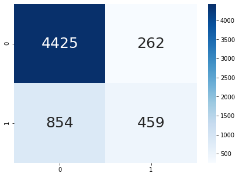

```python
fig, ax = plt.subplots(figsize=(7,5))         # Sample figsize in inches
sns.heatmap(conf_mat, annot=True, ax=ax, cmap='Blues', annot_kws={"size": 25},fmt="d")
```